# Explore and Summarize white win quality by abdulazez alsulaiman

```
## 'data.frame':    4898 obs. of  13 variables:
##  $ X                   : int  1 2 3 4 5 6 7 8 9 10 ...
##  $ fixed.acidity       : num  7 6.3 8.1 7.2 7.2 8.1 6.2 7 6.3 8.1 ...
##  $ volatile.acidity    : num  0.27 0.3 0.28 0.23 0.23 0.28 0.32 0.27 0.3 0.22 ...
##  $ citric.acid         : num  0.36 0.34 0.4 0.32 0.32 0.4 0.16 0.36 0.34 0.43 ...
##  $ residual.sugar      : num  20.7 1.6 6.9 8.5 8.5 6.9 7 20.7 1.6 1.5 ...
##  $ chlorides           : num  0.045 0.049 0.05 0.058 0.058 0.05 0.045 0.045 0.049 0.044 ...
##  $ free.sulfur.dioxide : num  45 14 30 47 47 30 30 45 14 28 ...
##  $ total.sulfur.dioxide: num  170 132 97 186 186 97 136 170 132 129 ...
##  $ density             : num  1.001 0.994 0.995 0.996 0.996 ...
##  $ pH                  : num  3 3.3 3.26 3.19 3.19 3.26 3.18 3 3.3 3.22 ...
##  $ sulphates           : num  0.45 0.49 0.44 0.4 0.4 0.44 0.47 0.45 0.49 0.45 ...
##  $ alcohol             : num  8.8 9.5 10.1 9.9 9.9 10.1 9.6 8.8 9.5 11 ...
##  $ quality             : int  6 6 6 6 6 6 6 6 6 6 ...
```

```
##        X        fixed.acidity    volatile.acidity  citric.acid
##  Min.   :   1   Min.   : 3.800   Min.   :0.0800   Min.   :0.0000
##  1st Qu.:1225   1st Qu.: 6.300   1st Qu.:0.2100   1st Qu.:0.2700
##  Median :2450   Median : 6.800   Median :0.2600   Median :0.3200
##  Mean   :2450   Mean   : 6.855   Mean   :0.2782   Mean   :0.3342
##  3rd Qu.:3674   3rd Qu.: 7.300   3rd Qu.:0.3200   3rd Qu.:0.3900
##  Max.   :4898   Max.   :14.200   Max.   :1.1000   Max.   :1.6600
##  residual.sugar     chlorides       free.sulfur.dioxide
##  Min.   : 0.600   Min.   :0.00900   Min.   :  2.00
##  1st Qu.: 1.700   1st Qu.:0.03600   1st Qu.: 23.00
##  Median : 5.200   Median :0.04300   Median : 34.00
##  Mean   : 6.391   Mean   :0.04577   Mean   : 35.31
##  3rd Qu.: 9.900   3rd Qu.:0.05000   3rd Qu.: 46.00
##  Max.   :65.800   Max.   :0.34600   Max.   :289.00
##  total.sulfur.dioxide    density             pH          sulphates
##  Min.   :  9.0        Min.   :0.9871   Min.   :2.720   Min.   :0.2200
##  1st Qu.:108.0        1st Qu.:0.9917   1st Qu.:3.090   1st Qu.:0.4100
##  Median :134.0        Median :0.9937   Median :3.180   Median :0.4700
##  Mean   :138.4        Mean   :0.9940   Mean   :3.188   Mean   :0.4898
##  3rd Qu.:167.0        3rd Qu.:0.9961   3rd Qu.:3.280   3rd Qu.:0.5500
##  Max.   :440.0        Max.   :1.0390   Max.   :3.820   Max.   :1.0800
##     alcohol         quality
##  Min.   : 8.00   Min.   :3.000
##  1st Qu.: 9.50   1st Qu.:5.000
##  Median :10.40   Median :6.000
##  Mean   :10.51   Mean   :5.878
##  3rd Qu.:11.40   3rd Qu.:6.000
##  Max.   :14.20   Max.   :9.000
```

```
## 'data.frame':    4898 obs. of  12 variables:
##  $ fixed.acidity       : num  7 6.3 8.1 7.2 7.2 8.1 6.2 7 6.3 8.1 ...
##  $ volatile.acidity    : num  0.27 0.3 0.28 0.23 0.23 0.28 0.32 0.27 0.3 0.22 ...
##  $ citric.acid         : num  0.36 0.34 0.4 0.32 0.32 0.4 0.16 0.36 0.34 0.43 ...
##  $ residual.sugar      : num  20.7 1.6 6.9 8.5 8.5 6.9 7 20.7 1.6 1.5 ...
##  $ chlorides           : num  0.045 0.049 0.05 0.058 0.058 0.05 0.045 0.045 0.049 0.044 ...
##  $ free.sulfur.dioxide : num  45 14 30 47 47 30 30 45 14 28 ...
##  $ total.sulfur.dioxide: num  170 132 97 186 186 97 136 170 132 129 ...
##  $ density             : num  1.001 0.994 0.995 0.996 0.996 ...
##  $ pH                  : num  3 3.3 3.26 3.19 3.19 3.26 3.18 3 3.3 3.22 ...
##  $ sulphates           : num  0.45 0.49 0.44 0.4 0.4 0.44 0.47 0.45 0.49 0.45 ...
##  $ alcohol             : num  8.8 9.5 10.1 9.9 9.9 10.1 9.6 8.8 9.5 11 ...
##  $ quality             : int  6 6 6 6 6 6 6 6 6 6 ...
```

# Univariate Plots Section

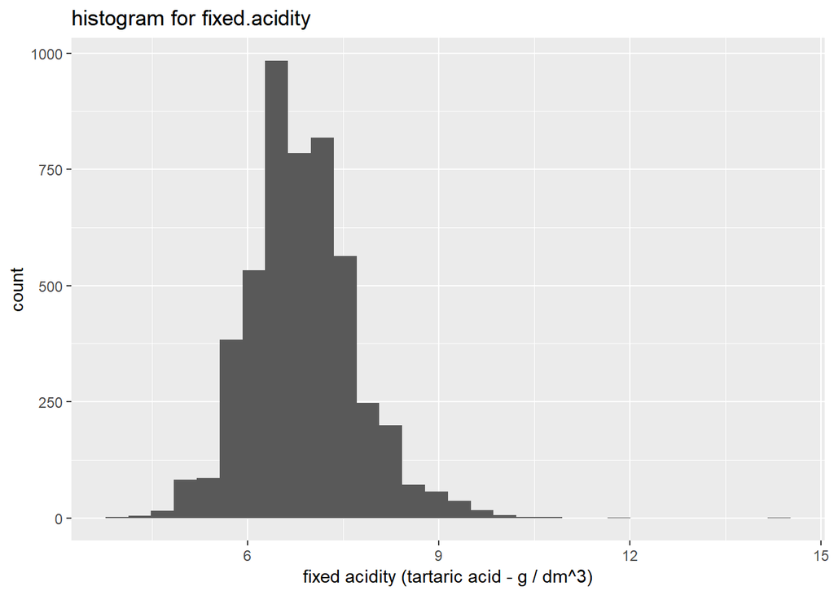

as we can see in the apove graph the data is normaly distributed between 5 to 9

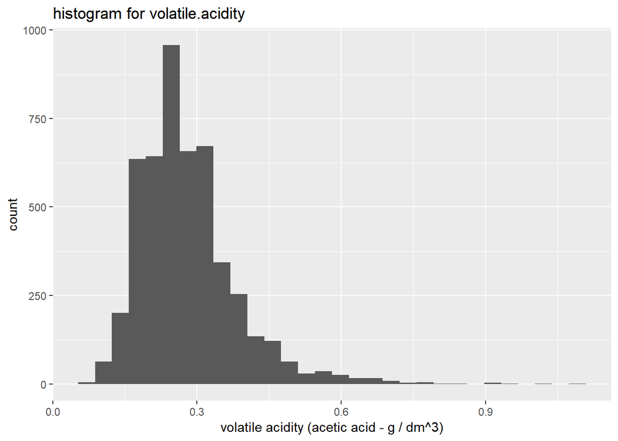

as we can see in the apove graph the most tested data have low volatile acidity

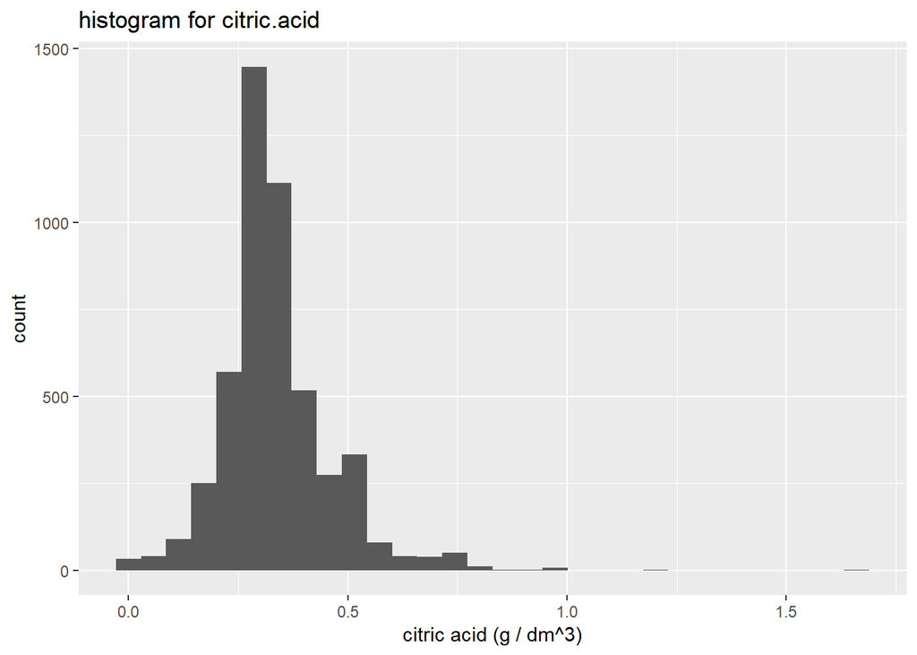

as we can see in the apove graph the data is normaly distributed between 0 to 0.5

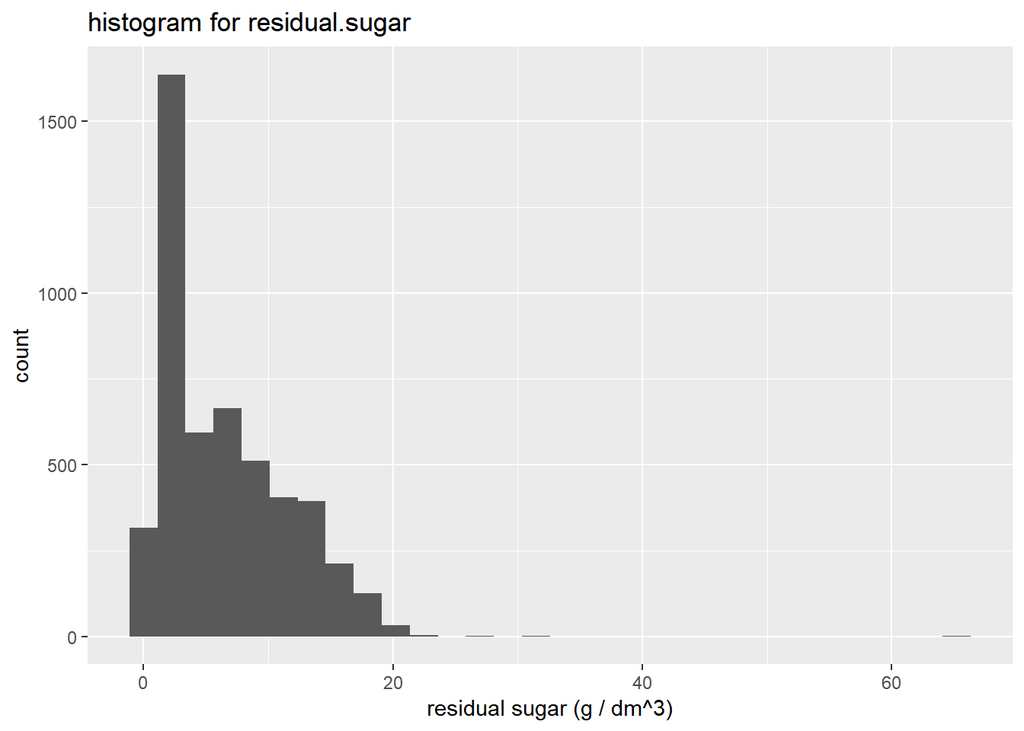

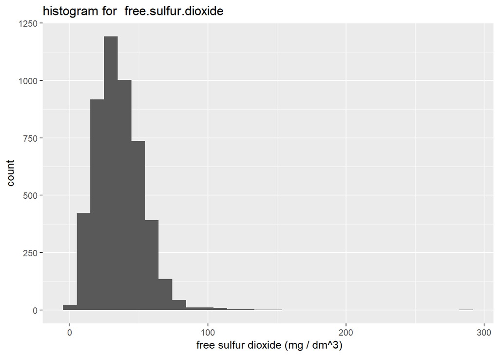

as we can see in the apove graphthe free sulfur dioxide is normaly distributed

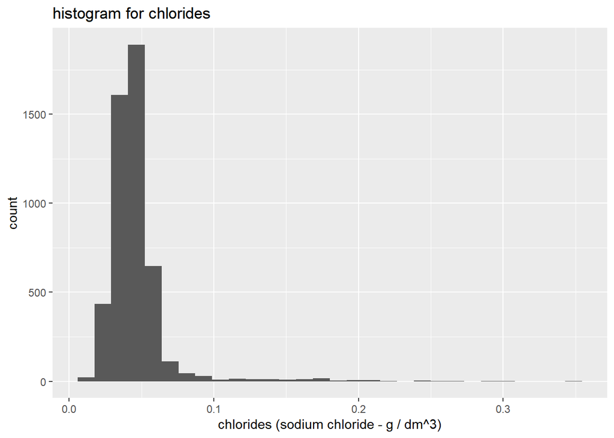

as shown in the graph 6 the most data have chlorides between 0 to 0.1

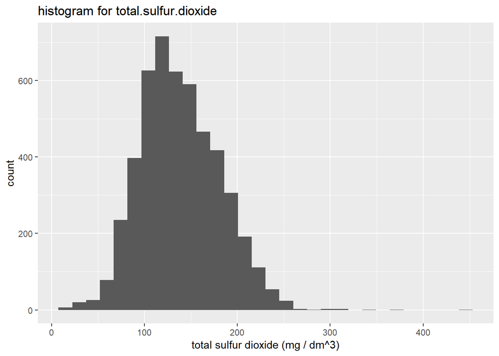

as shown in the apove graph the total sulfur dioxide is normaly distributed

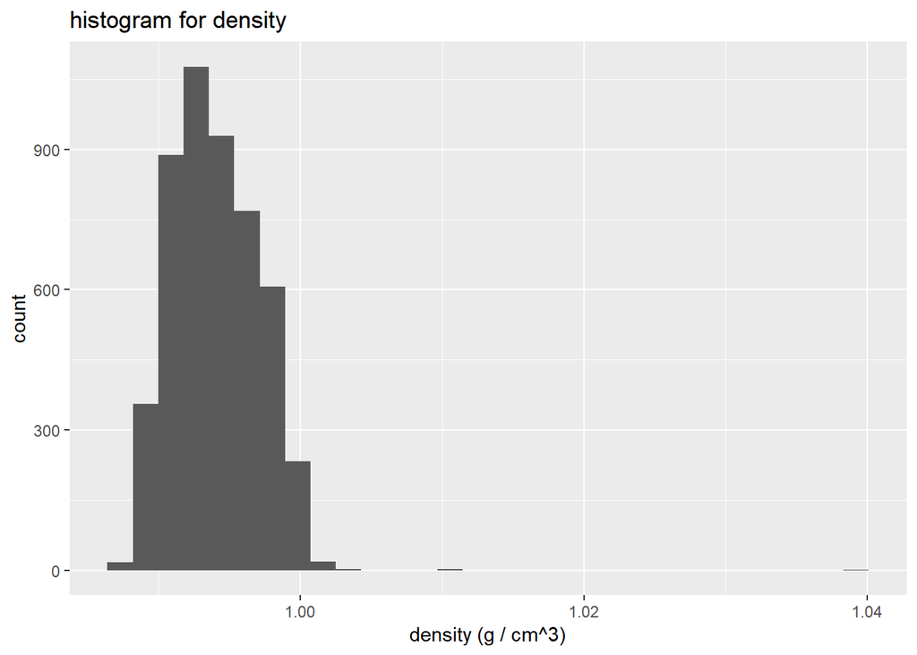

as we can see in the apove graph the most data have density lower than 1

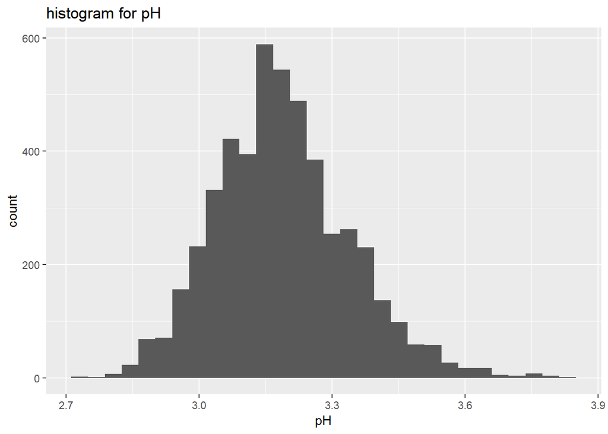

as we can see in the apove graph the pH data is normaly distributed

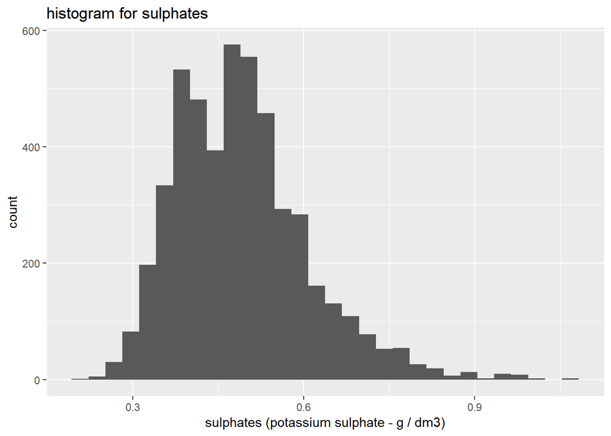

as we can see in the apove graph the most data have sulphates between 0.3 and 0.6

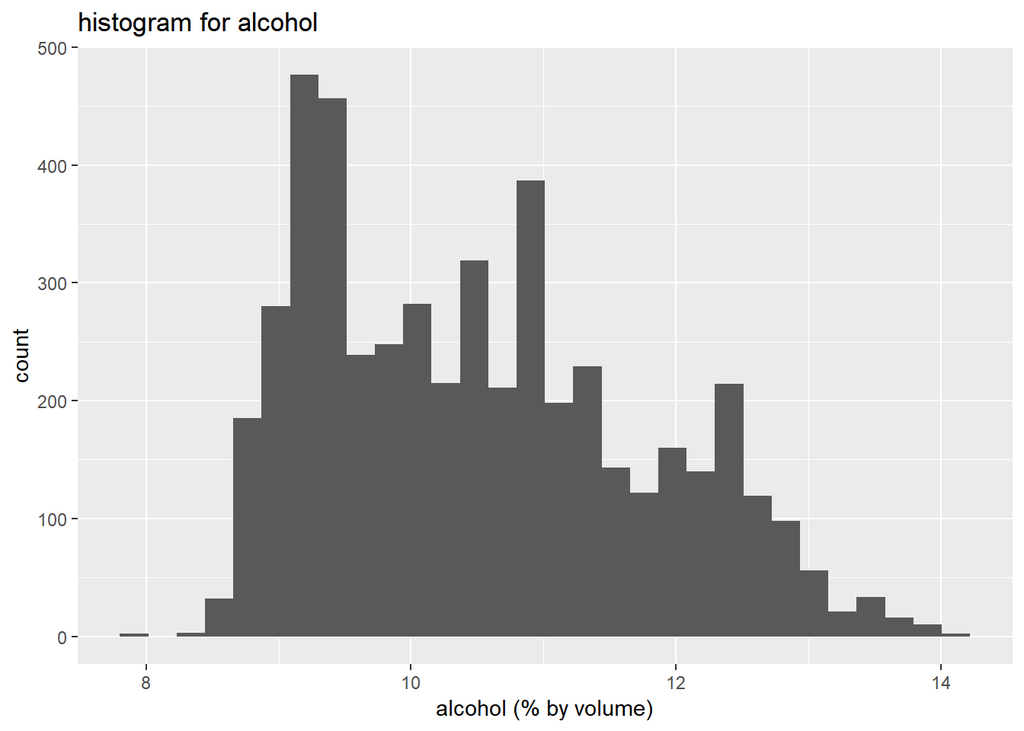

as we can see in the apove graph there is few data have higher alcohol percentage

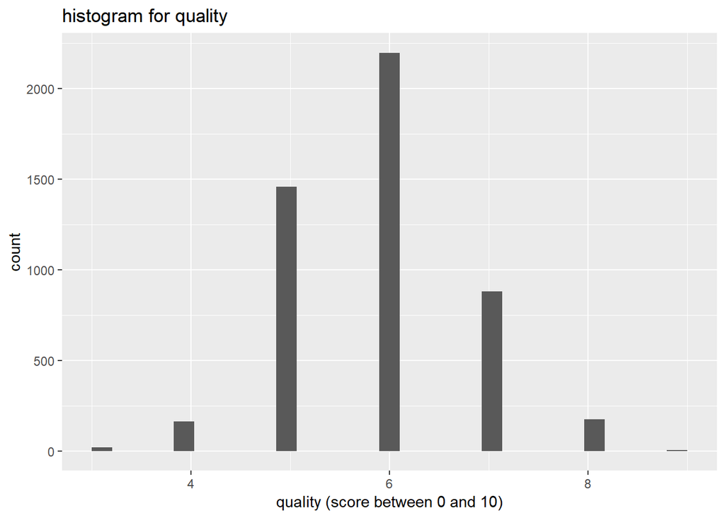

as shown in the apove graphmost most common quality in tha data is 6, over 2000 samples have it.

# Univariate Analysis

### What is the structure of your dataset?

there is 13 variables in my dataset and 4898 rwos

### What is/are the main feature(s) of interest in your dataset?

1- quality , 2-pH , 3-alcohol , 4-density , 5-residual.sugar

### What other features in the dataset do you think will help support your investigation into your feature(s) of interest?

i delet column X becuase it makes noise in the data and its useless

# Bivariate Plots Section

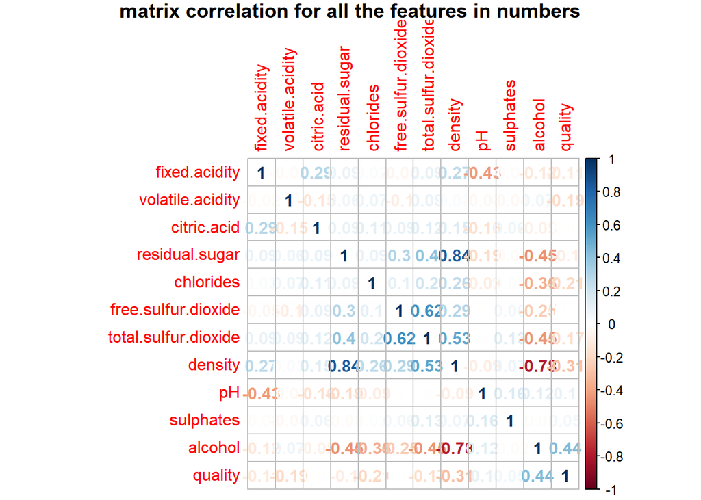

the apove graph shows the matrix correlation for all the features in numbers

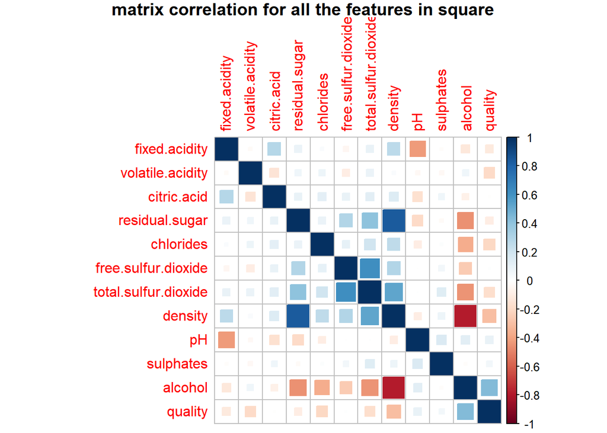

the apove graph shows the matrix correlation for all the features in squares

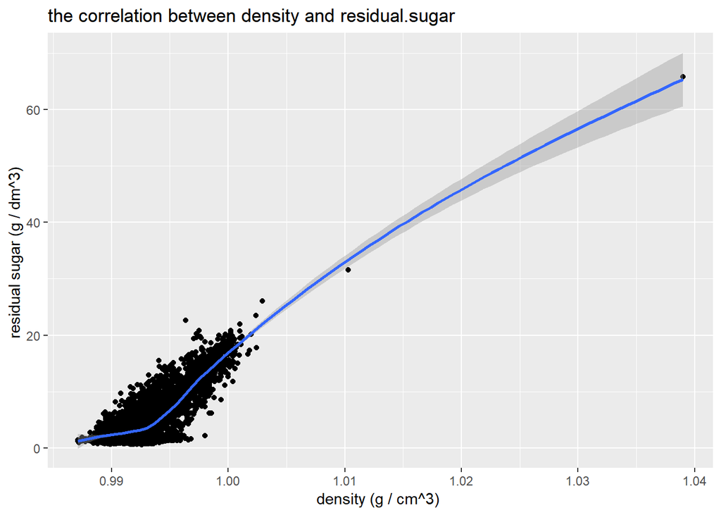

in the apove graph we can see the the relationship between density and residual sugar

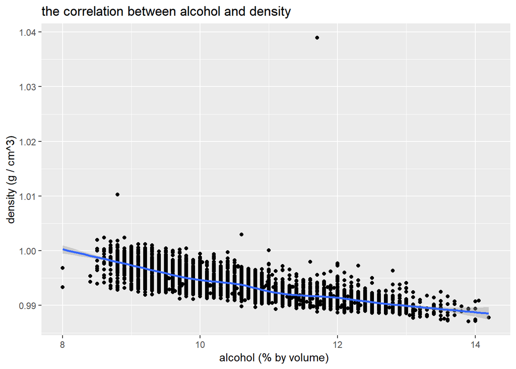

in the apove graph we can see the relationship between alcohol and density

[figure not shown]

in the apove graph we can see the relationship between free sulfur dioxide and residual.sugar

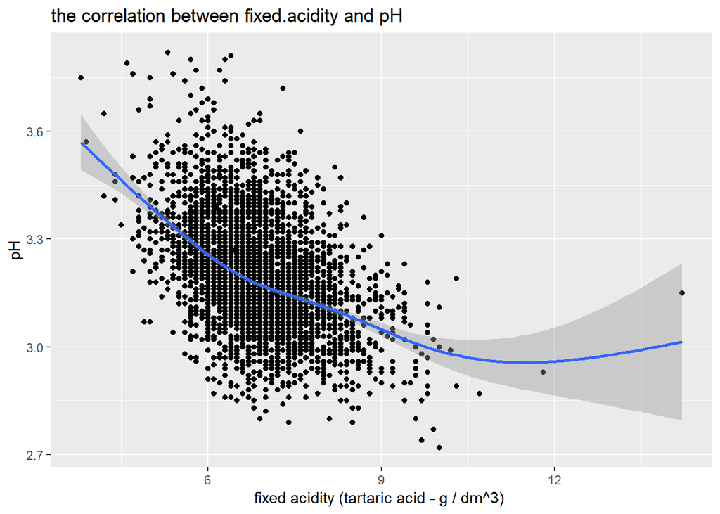

in the apove graph we can see the relationship between fixed acidity and pH

# Bivariate Analysis

### Talk about some of the relationships you observed in this part of the investigation. How did the feature(s) of interest vary with other features in the dataset?

# Multi variate Plots Section

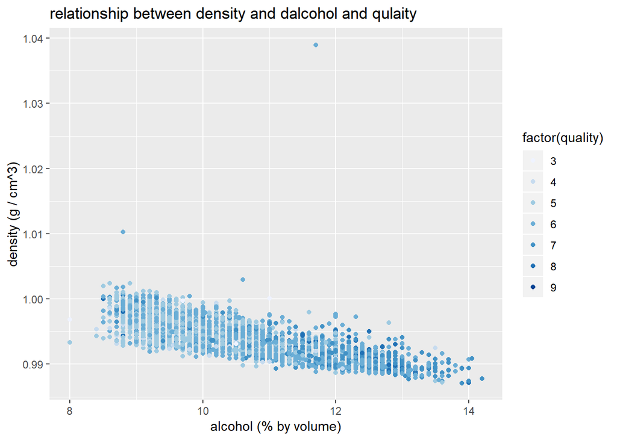

in the apove graph we can see the relationship between alcohol, density and quality

[figure not shown]

in the apove graph we can see the the relationship between density , residual sugar and quality

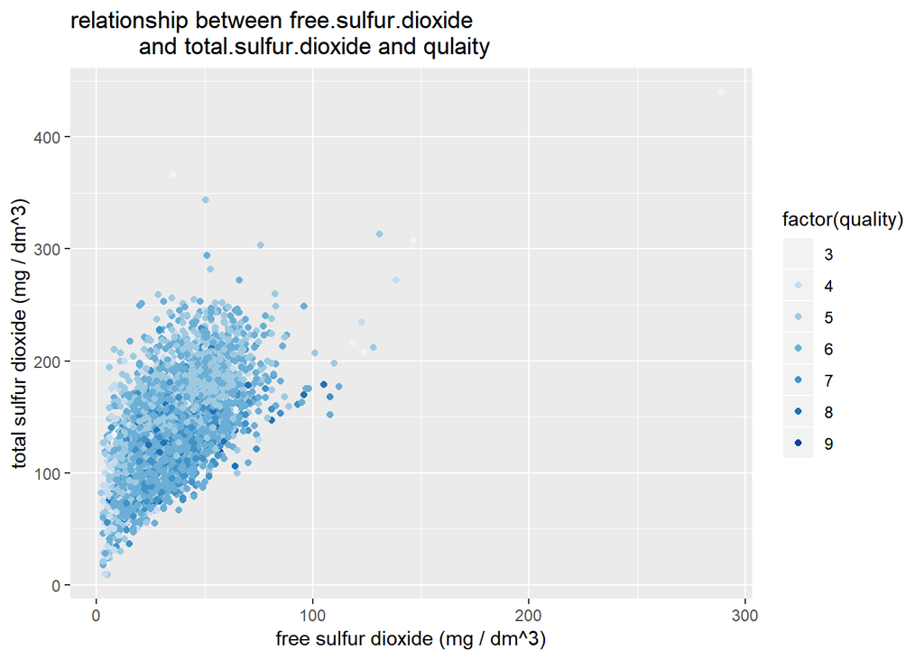

in the apove graph we can see relationship between free.sulfur.dioxide and total.sulfur.dioxide and qulaity

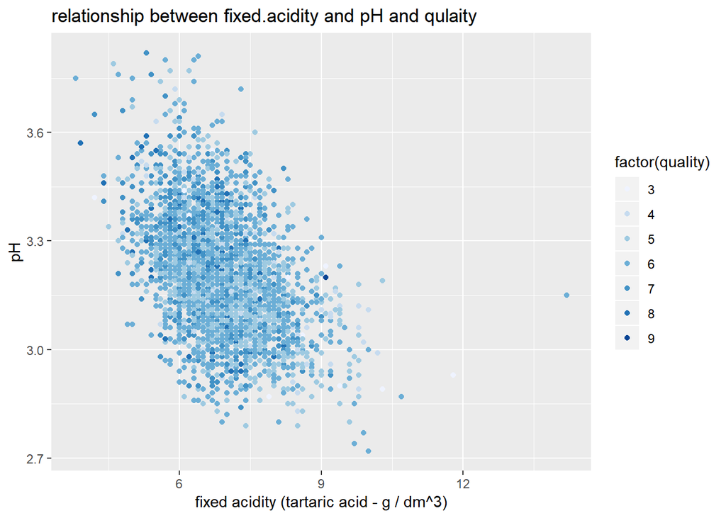

in the apove graph we can see the relationship between fixed acidity , pH and quality

# multi varaible Analysis

### Talk about some of the relationships you observed in this part of the investigation. Were there features that strengthened each other in terms of looking at your feature(s) of interest?

# Final Plots and Summary

### Plot One

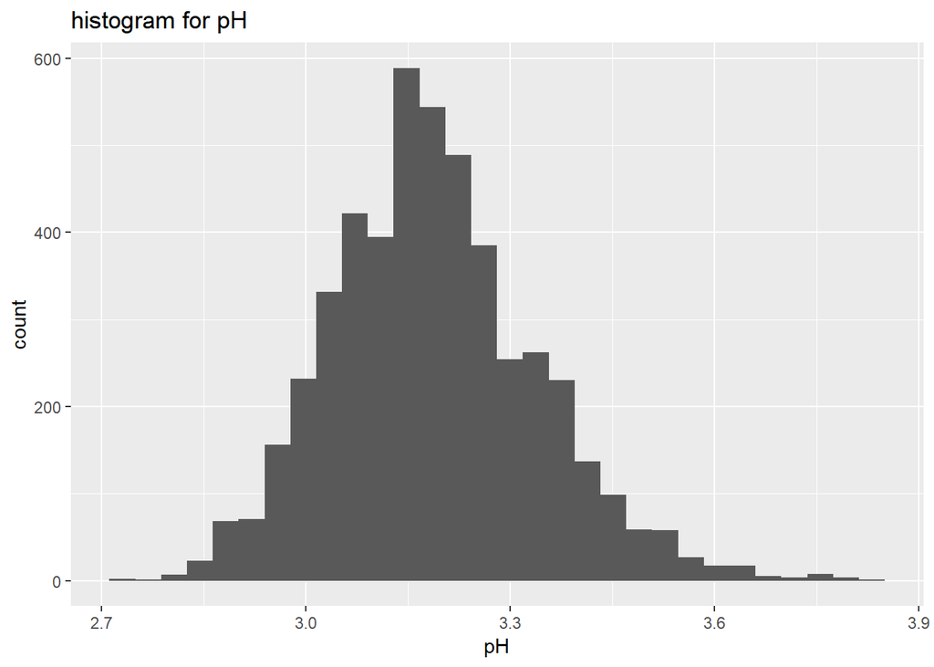

### Description One

as we can see in the apove graph the data in pH is noramily distrebuted

### Plot Two

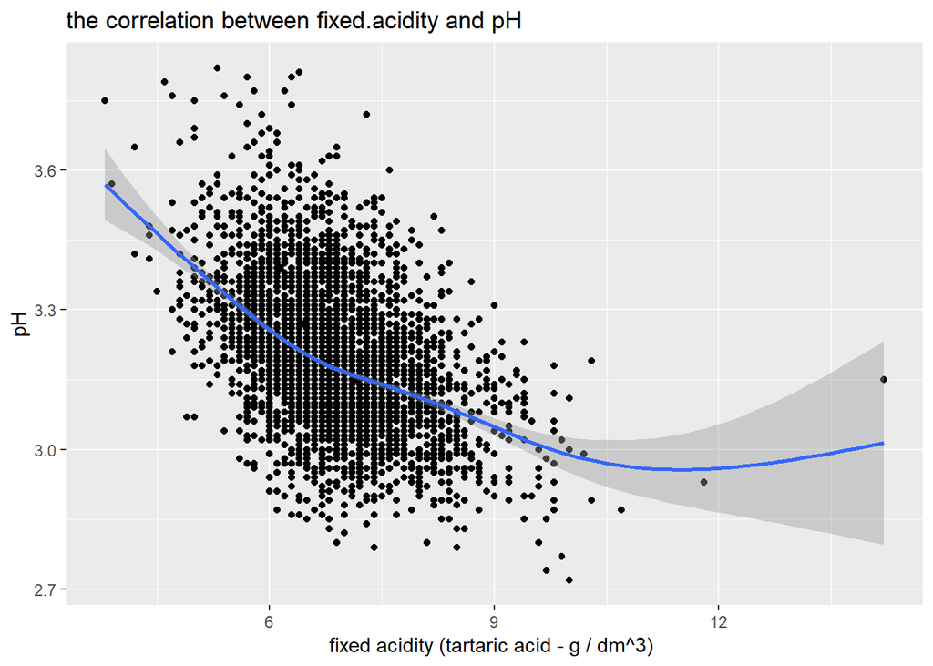

### Description Two

[figure not shown]

### Description Three

as we can see in the apove graph that if the alcohol is higer and the densety is lower then the qulaity will be better ——

# Reflection

struggles : 1- i don`t drink win and never see one , so it was not make sense 2-the quality of the data is good but i had to make some chamges

future work :

most of the tested win their qulaity is 6 and few 8 , it should be equal size of all diffirent qulaity level, so as a future idea, i think we need to collect more data with other qualities